# Risk Factor Analysis

## Outcome Variable

**Outcome Variable:** ever_sstunted

## Predictor Variables

**Intervention Variable:** nhh

**Adjustment Set:**

- arm
- W_mage
- meducyrs
- feducyrs
- W_mhtcm
- W_mwtkg
- W_mbmi
- W_nrooms
- impfloor
- impsan
- safeh20
- delta_W_mage
- delta_meducyrs
- delta_feducyrs
- delta_W_mhtcm
- delta_W_mwtkg
- delta_W_mbmi
- delta_W_nrooms
- delta_impfloor
- delta_impsan
- delta_safeh20

## Stratifying Variables

The analysis was stratified on these variable(s):

- agecat
- studyid
- country

## Data Summary

| agecat | studyid | country | nhh | ever_sstunted | n_cell | n |
| --- | --- | --- | --- | --- | --- | --- |
| 0-24 months | ki1000108-IRC | INDIA | 3 or less | 0 | 47 | 410 |
| 0-24 months | ki1000108-IRC | INDIA | 3 or less | 1 | 11 | 410 |
| 0-24 months | ki1000108-IRC | INDIA | 4-5 | 0 | 114 | 410 |
| 0-24 months | ki1000108-IRC | INDIA | 4-5 | 1 | 44 | 410 |
| 0-24 months | ki1000108-IRC | INDIA | 6-7 | 0 | 80 | 410 |
| 0-24 months | ki1000108-IRC | INDIA | 6-7 | 1 | 27 | 410 |
| 0-24 months | ki1000108-IRC | INDIA | 8+ | 0 | 67 | 410 |
| 0-24 months | ki1000108-IRC | INDIA | 8+ | 1 | 20 | 410 |
| 0-24 months | ki1000304b-SAS-FoodSuppl | INDIA | 3 or less | 0 | 28 | 418 |
| 0-24 months | ki1000304b-SAS-FoodSuppl | INDIA | 3 or less | 1 | 10 | 418 |
| 0-24 months | ki1000304b-SAS-FoodSuppl | INDIA | 4-5 | 0 | 97 | 418 |
| 0-24 months | ki1000304b-SAS-FoodSuppl | INDIA | 4-5 | 1 | 86 | 418 |
| 0-24 months | ki1000304b-SAS-FoodSuppl | INDIA | 6-7 | 0 | 58 | 418 |
| 0-24 months | ki1000304b-SAS-FoodSuppl | INDIA | 6-7 | 1 | 69 | 418 |
| 0-24 months | ki1000304b-SAS-FoodSuppl | INDIA | 8+ | 0 | 34 | 418 |
| 0-24 months | ki1000304b-SAS-FoodSuppl | INDIA | 8+ | 1 | 36 | 418 |
| 0-24 months | ki1017093-NIH-Birth | BANGLADESH | 3 or less | 0 | 87 | 629 |
| 0-24 months | ki1017093-NIH-Birth | BANGLADESH | 3 or less | 1 | 30 | 629 |
| 0-24 months | ki1017093-NIH-Birth | BANGLADESH | 4-5 | 0 | 172 | 629 |
| 0-24 months | ki1017093-NIH-Birth | BANGLADESH | 4-5 | 1 | 92 | 629 |
| 0-24 months | ki1017093-NIH-Birth | BANGLADESH | 6-7 | 0 | 98 | 629 |
| 0-24 months | ki1017093-NIH-Birth | BANGLADESH | 6-7 | 1 | 44 | 629 |
| 0-24 months | ki1017093-NIH-Birth | BANGLADESH | 8+ | 0 | 76 | 629 |
| 0-24 months | ki1017093-NIH-Birth | BANGLADESH | 8+ | 1 | 30 | 629 |
| 0-24 months | ki1017093b-PROVIDE | BANGLADESH | 3 or less | 0 | 117 | 700 |
| 0-24 months | ki1017093b-PROVIDE | BANGLADESH | 3 or less | 1 | 23 | 700 |
| 0-24 months | ki1017093b-PROVIDE | BANGLADESH | 4-5 | 0 | 280 | 700 |
| 0-24 months | ki1017093b-PROVIDE | BANGLADESH | 4-5 | 1 | 42 | 700 |
| 0-24 months | ki1017093b-PROVIDE | BANGLADESH | 6-7 | 0 | 135 | 700 |
| 0-24 months | ki1017093b-PROVIDE | BANGLADESH | 6-7 | 1 | 16 | 700 |

[output cut: 66 more lines]

The following strata were considered:

- agecat: 0-24 months, studyid: ki1000108-IRC, country: INDIA
- agecat: 0-24 months, studyid: ki1000304b-SAS-FoodSuppl, country: INDIA
- agecat: 0-24 months, studyid: ki1017093-NIH-Birth, country: BANGLADESH
- agecat: 0-24 months, studyid: ki1017093b-PROVIDE, country: BANGLADESH
- agecat: 0-24 months, studyid: ki1017093c-NIH-Crypto, country: BANGLADESH
- agecat: 0-24 months, studyid: ki1148112-LCNI-5, country: MALAWI
- agecat: 0-6 months, studyid: ki1000108-IRC, country: INDIA
- agecat: 0-6 months, studyid: ki1000304b-SAS-FoodSuppl, country: INDIA
- agecat: 0-6 months, studyid: ki1017093-NIH-Birth, country: BANGLADESH
- agecat: 0-6 months, studyid: ki1017093b-PROVIDE, country: BANGLADESH
- agecat: 0-6 months, studyid: ki1017093c-NIH-Crypto, country: BANGLADESH
- agecat: 0-6 months, studyid: ki1148112-LCNI-5, country: MALAWI

### Dropped Strata

Some strata were dropped due to rare outcomes:

- agecat: 0-6 months, studyid: ki1000304b-SAS-FoodSuppl, country: INDIA
- agecat: 0-6 months, studyid: ki1017093b-PROVIDE, country: BANGLADESH
- agecat: 0-6 months, studyid: ki1148112-LCNI-5, country: MALAWI

## Methods Detail

We’re interested in the causal parameters $E[Y_a]$ for all values of $a \in \mathcal{A}$. These parameters represent the mean outcome if, possibly contrary to fact, we intervened to set all units to have $A=a$. Under the randomization and positivity assumptions, these are identified by the statistical parameters $\psi_a=E_W[E_{Y|A,W}(Y|A=a,W)]$. In addition, we’re interested in the mean of $Y$, $E[Y]$ under no intervention (the observed mean). We will estimate these parameters by using SuperLearner to fit the relevant likelihood factors – $E_{Y|A,W}(Y|A=a,W)$ and $p(A=a|W)$, and then updating our likelihood fit using a joint TMLE.

For unadjusted analyses ($W=\{\}$), initial likelihoods were estimated using Lrnr_glm to estimate the simple $E(Y|A)$ and Lrnr_mean to estimate $p(A)$. For adjusted analyses, a small library containing Lrnr_glmnet, Lrnr_xgboost, and Lrnr_mean was used.

Having estimated these parameters, we will then use the delta method to estimate relative risks and attributable risks relative to a prespecified baseline level of $A$.

# Results Detail

## Results Plots

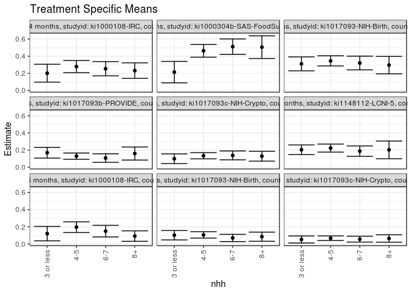

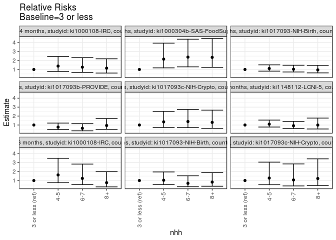

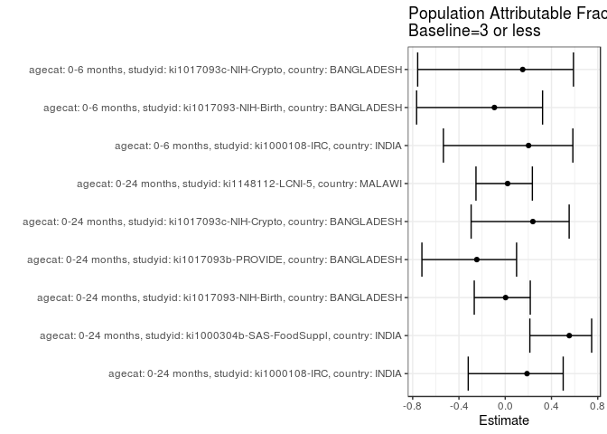

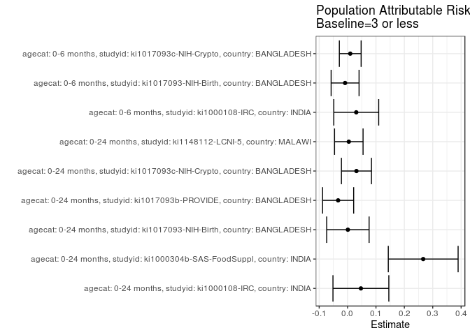

## Results Table

### Parameter: TSM

| agecat | studyid | country | intervention_level | baseline_level | estimate | ci_lower | ci_upper |
| --- | --- | --- | --- | --- | --- | --- | --- |
| 0-24 months | ki1000108-IRC | INDIA | 3 or less | NA | 0.2018536 | 0.0975007 | 0.3062064 |
| 0-24 months | ki1000108-IRC | INDIA | 4-5 | NA | 0.2789550 | 0.2085176 | 0.3493925 |
| 0-24 months | ki1000108-IRC | INDIA | 6-7 | NA | 0.2539799 | 0.1709370 | 0.3370229 |
| 0-24 months | ki1000108-IRC | INDIA | 8+ | NA | 0.2319076 | 0.1416307 | 0.3221846 |
| 0-24 months | ki1000304b-SAS-FoodSuppl | INDIA | 3 or less | NA | 0.2144596 | 0.0895056 | 0.3394137 |
| 0-24 months | ki1000304b-SAS-FoodSuppl | INDIA | 4-5 | NA | 0.4631329 | 0.3888320 | 0.5374338 |
| 0-24 months | ki1000304b-SAS-FoodSuppl | INDIA | 6-7 | NA | 0.5110076 | 0.4208219 | 0.6011932 |
| 0-24 months | ki1000304b-SAS-FoodSuppl | INDIA | 8+ | NA | 0.5052595 | 0.3731165 | 0.6374025 |
| 0-24 months | ki1017093-NIH-Birth | BANGLADESH | 3 or less | NA | 0.3105255 | 0.2293823 | 0.3916687 |
| 0-24 months | ki1017093-NIH-Birth | BANGLADESH | 4-5 | NA | 0.3454765 | 0.2863667 | 0.4045863 |
| 0-24 months | ki1017093-NIH-Birth | BANGLADESH | 6-7 | NA | 0.3205201 | 0.2406050 | 0.4004351 |
| 0-24 months | ki1017093-NIH-Birth | BANGLADESH | 8+ | NA | 0.2960771 | 0.1945057 | 0.3976485 |
| 0-24 months | ki1017093b-PROVIDE | BANGLADESH | 3 or less | NA | 0.1690299 | 0.1067249 | 0.2313349 |
| 0-24 months | ki1017093b-PROVIDE | BANGLADESH | 4-5 | NA | 0.1293206 | 0.0927608 | 0.1658803 |
| 0-24 months | ki1017093b-PROVIDE | BANGLADESH | 6-7 | NA | 0.1071601 | 0.0574397 | 0.1568806 |
| 0-24 months | ki1017093b-PROVIDE | BANGLADESH | 8+ | NA | 0.1599036 | 0.0837518 | 0.2360554 |
| 0-24 months | ki1017093c-NIH-Crypto | BANGLADESH | 3 or less | NA | 0.0993714 | 0.0428426 | 0.1559003 |
| 0-24 months | ki1017093c-NIH-Crypto | BANGLADESH | 4-5 | NA | 0.1341877 | 0.0978123 | 0.1705630 |
| 0-24 months | ki1017093c-NIH-Crypto | BANGLADESH | 6-7 | NA | 0.1380837 | 0.0865855 | 0.1895819 |
| 0-24 months | ki1017093c-NIH-Crypto | BANGLADESH | 8+ | NA | 0.1286901 | 0.0713434 | 0.1860367 |
| 0-24 months | ki1148112-LCNI-5 | MALAWI | 3 or less | NA | 0.2037399 | 0.1472808 | 0.2601991 |
| 0-24 months | ki1148112-LCNI-5 | MALAWI | 4-5 | NA | 0.2233333 | 0.1764706 | 0.2701960 |
| 0-24 months | ki1148112-LCNI-5 | MALAWI | 6-7 | NA | 0.1875671 | 0.1269297 | 0.2482046 |
| 0-24 months | ki1148112-LCNI-5 | MALAWI | 8+ | NA | 0.2025363 | 0.0994257 | 0.3056470 |
| 0-6 months | ki1000108-IRC | INDIA | 3 or less | NA | 0.1206897 | 0.0367494 | 0.2046299 |
| 0-6 months | ki1000108-IRC | INDIA | 4-5 | NA | 0.1962025 | 0.1342049 | 0.2582002 |
| 0-6 months | ki1000108-IRC | INDIA | 6-7 | NA | 0.1495327 | 0.0818803 | 0.2171851 |
| 0-6 months | ki1000108-IRC | INDIA | 8+ | NA | 0.0919540 | 0.0311604 | 0.1527477 |
| 0-6 months | ki1017093-NIH-Birth | BANGLADESH | 3 or less | NA | 0.1025641 | 0.0475467 | 0.1575815 |
| 0-6 months | ki1017093-NIH-Birth | BANGLADESH | 4-5 | NA | 0.1060606 | 0.0688880 | 0.1432332 |
| 0-6 months | ki1017093-NIH-Birth | BANGLADESH | 6-7 | NA | 0.0704225 | 0.0283064 | 0.1125386 |
| 0-6 months | ki1017093-NIH-Birth | BANGLADESH | 8+ | NA | 0.0849057 | 0.0317999 | 0.1380115 |
| 0-6 months | ki1017093c-NIH-Crypto | BANGLADESH | 3 or less | NA | 0.0526316 | 0.0116145 | 0.0936487 |
| 0-6 months | ki1017093c-NIH-Crypto | BANGLADESH | 4-5 | NA | 0.0672515 | 0.0406898 | 0.0938131 |
| 0-6 months | ki1017093c-NIH-Crypto | BANGLADESH | 6-7 | NA | 0.0561798 | 0.0223297 | 0.0900298 |
| 0-6 months | ki1017093c-NIH-Crypto | BANGLADESH | 8+ | NA | 0.0645161 | 0.0212472 | 0.1077851 |

### Parameter: E(Y)

| agecat | studyid | country | intervention_level | baseline_level | estimate | ci_lower | ci_upper |
| --- | --- | --- | --- | --- | --- | --- | --- |
| 0-24 months | ki1000108-IRC | INDIA | NA | NA | 0.2487805 | 0.2068840 | 0.2906770 |
| 0-24 months | ki1000304b-SAS-FoodSuppl | INDIA | NA | NA | 0.4808612 | 0.4329065 | 0.5288160 |
| 0-24 months | ki1017093-NIH-Birth | BANGLADESH | NA | NA | 0.3116057 | 0.2753823 | 0.3478292 |
| 0-24 months | ki1017093b-PROVIDE | BANGLADESH | NA | NA | 0.1357143 | 0.1103250 | 0.1611036 |
| 0-24 months | ki1017093c-NIH-Crypto | BANGLADESH | NA | NA | 0.1306069 | 0.1066024 | 0.1546113 |
| 0-24 months | ki1148112-LCNI-5 | MALAWI | NA | NA | 0.2080783 | 0.1802263 | 0.2359304 |
| 0-6 months | ki1000108-IRC | INDIA | NA | NA | 0.1512195 | 0.1164988 | 0.1859402 |
| 0-6 months | ki1017093-NIH-Birth | BANGLADESH | NA | NA | 0.0937997 | 0.0709973 | 0.1166021 |
| 0-6 months | ki1017093c-NIH-Crypto | BANGLADESH | NA | NA | 0.0620053 | 0.0448256 | 0.0791849 |

### Parameter: RR

| agecat | studyid | country | intervention_level | baseline_level | estimate | ci_lower | ci_upper |
| --- | --- | --- | --- | --- | --- | --- | --- |
| 0-24 months | ki1000108-IRC | INDIA | 3 or less | 3 or less | 1.0000000 | 1.0000000 | 1.000000 |
| 0-24 months | ki1000108-IRC | INDIA | 4-5 | 3 or less | 1.3819673 | 0.7774031 | 2.456684 |
| 0-24 months | ki1000108-IRC | INDIA | 6-7 | 3 or less | 1.2582385 | 0.6822431 | 2.320528 |
| 0-24 months | ki1000108-IRC | INDIA | 8+ | 3 or less | 1.1488904 | 0.6011447 | 2.195726 |
| 0-24 months | ki1000304b-SAS-FoodSuppl | INDIA | 3 or less | 3 or less | 1.0000000 | 1.0000000 | 1.000000 |
| 0-24 months | ki1000304b-SAS-FoodSuppl | INDIA | 4-5 | 3 or less | 2.1595342 | 1.1818185 | 3.946112 |
| 0-24 months | ki1000304b-SAS-FoodSuppl | INDIA | 6-7 | 3 or less | 2.3827681 | 1.2943038 | 4.386593 |
| 0-24 months | ki1000304b-SAS-FoodSuppl | INDIA | 8+ | 3 or less | 2.3559657 | 1.2431234 | 4.465023 |
| 0-24 months | ki1017093-NIH-Birth | BANGLADESH | 3 or less | 3 or less | 1.0000000 | 1.0000000 | 1.000000 |
| 0-24 months | ki1017093-NIH-Birth | BANGLADESH | 4-5 | 3 or less | 1.1125544 | 0.8154013 | 1.517998 |
| 0-24 months | ki1017093-NIH-Birth | BANGLADESH | 6-7 | 3 or less | 1.0321859 | 0.7217010 | 1.476246 |
| 0-24 months | ki1017093-NIH-Birth | BANGLADESH | 8+ | 3 or less | 0.9534712 | 0.6197408 | 1.466915 |
| 0-24 months | ki1017093b-PROVIDE | BANGLADESH | 3 or less | 3 or less | 1.0000000 | 1.0000000 | 1.000000 |
| 0-24 months | ki1017093b-PROVIDE | BANGLADESH | 4-5 | 3 or less | 0.7650751 | 0.4810014 | 1.216920 |
| 0-24 months | ki1017093b-PROVIDE | BANGLADESH | 6-7 | 3 or less | 0.6339715 | 0.3504317 | 1.146928 |
| 0-24 months | ki1017093b-PROVIDE | BANGLADESH | 8+ | 3 or less | 0.9460080 | 0.5182430 | 1.726856 |
| 0-24 months | ki1017093c-NIH-Crypto | BANGLADESH | 3 or less | 3 or less | 1.0000000 | 1.0000000 | 1.000000 |
| 0-24 months | ki1017093c-NIH-Crypto | BANGLADESH | 4-5 | 3 or less | 1.3503645 | 0.7202825 | 2.531624 |
| 0-24 months | ki1017093c-NIH-Crypto | BANGLADESH | 6-7 | 3 or less | 1.3895714 | 0.7048396 | 2.739501 |
| 0-24 months | ki1017093c-NIH-Crypto | BANGLADESH | 8+ | 3 or less | 1.2950408 | 0.6299976 | 2.662123 |
| 0-24 months | ki1148112-LCNI-5 | MALAWI | 3 or less | 3 or less | 1.0000000 | 1.0000000 | 1.000000 |
| 0-24 months | ki1148112-LCNI-5 | MALAWI | 4-5 | 3 or less | 1.0961685 | 0.7745295 | 1.551375 |
| 0-24 months | ki1148112-LCNI-5 | MALAWI | 6-7 | 3 or less | 0.9206204 | 0.6013780 | 1.409333 |
| 0-24 months | ki1148112-LCNI-5 | MALAWI | 8+ | 3 or less | 0.9940926 | 0.5568758 | 1.774579 |
| 0-6 months | ki1000108-IRC | INDIA | 3 or less | 3 or less | 1.0000000 | 1.0000000 | 1.000000 |
| 0-6 months | ki1000108-IRC | INDIA | 4-5 | 3 or less | 1.6256781 | 0.7572995 | 3.489807 |
| 0-6 months | ki1000108-IRC | INDIA | 6-7 | 3 or less | 1.2389853 | 0.5404161 | 2.840561 |
| 0-6 months | ki1000108-IRC | INDIA | 8+ | 3 or less | 0.7619048 | 0.2918463 | 1.989057 |
| 0-6 months | ki1017093-NIH-Birth | BANGLADESH | 3 or less | 3 or less | 1.0000000 | 1.0000000 | 1.000000 |
| 0-6 months | ki1017093-NIH-Birth | BANGLADESH | 4-5 | 3 or less | 1.0340909 | 0.5448490 | 1.962643 |
| 0-6 months | ki1017093-NIH-Birth | BANGLADESH | 6-7 | 3 or less | 0.6866197 | 0.3074793 | 1.533263 |
| 0-6 months | ki1017093-NIH-Birth | BANGLADESH | 8+ | 3 or less | 0.8278302 | 0.3631514 | 1.887099 |
| 0-6 months | ki1017093c-NIH-Crypto | BANGLADESH | 3 or less | 3 or less | 1.0000000 | 1.0000000 | 1.000000 |
| 0-6 months | ki1017093c-NIH-Crypto | BANGLADESH | 4-5 | 3 or less | 1.2777778 | 0.5333533 | 3.061228 |
| 0-6 months | ki1017093c-NIH-Crypto | BANGLADESH | 6-7 | 3 or less | 1.0674157 | 0.3985813 | 2.858579 |
| 0-6 months | ki1017093c-NIH-Crypto | BANGLADESH | 8+ | 3 or less | 1.2258064 | 0.4384209 | 3.427304 |

### Parameter: PAR

| agecat | studyid | country | intervention_level | baseline_level | estimate | ci_lower | ci_upper |
| --- | --- | --- | --- | --- | --- | --- | --- |
| 0-24 months | ki1000108-IRC | INDIA | 3 or less | NA | 0.0469269 | -0.0514769 | 0.1453308 |
| 0-24 months | ki1000304b-SAS-FoodSuppl | INDIA | 3 or less | NA | 0.2664016 | 0.1433936 | 0.3894096 |
| 0-24 months | ki1017093-NIH-Birth | BANGLADESH | 3 or less | NA | 0.0010802 | -0.0736446 | 0.0758051 |
| 0-24 months | ki1017093b-PROVIDE | BANGLADESH | 3 or less | NA | -0.0333156 | -0.0880769 | 0.0214457 |
| 0-24 months | ki1017093c-NIH-Crypto | BANGLADESH | 3 or less | NA | 0.0312354 | -0.0216783 | 0.0841492 |
| 0-24 months | ki1148112-LCNI-5 | MALAWI | 3 or less | NA | 0.0043384 | -0.0458813 | 0.0545582 |
| 0-6 months | ki1000108-IRC | INDIA | 3 or less | NA | 0.0305299 | -0.0485777 | 0.1096374 |
| 0-6 months | ki1017093-NIH-Birth | BANGLADESH | 3 or less | NA | -0.0087644 | -0.0579660 | 0.0404372 |
| 0-6 months | ki1017093c-NIH-Crypto | BANGLADESH | 3 or less | NA | 0.0093737 | -0.0289863 | 0.0477337 |

### Parameter: PAF

| agecat | studyid | country | intervention_level | baseline_level | estimate | ci_lower | ci_upper |
| --- | --- | --- | --- | --- | --- | --- | --- |
| 0-24 months | ki1000108-IRC | INDIA | 3 or less | NA | 0.1886278 | -0.3197423 | 0.5011716 |
| 0-24 months | ki1000304b-SAS-FoodSuppl | INDIA | 3 or less | NA | 0.5540093 | 0.2130705 | 0.7472357 |
| 0-24 months | ki1017093-NIH-Birth | BANGLADESH | 3 or less | NA | 0.0034667 | -0.2676240 | 0.2165826 |
| 0-24 months | ki1017093b-PROVIDE | BANGLADESH | 3 or less | NA | -0.2454834 | -0.7201856 | 0.0982201 |
| 0-24 months | ki1017093c-NIH-Crypto | BANGLADESH | 3 or less | NA | 0.2391561 | -0.2945773 | 0.5528398 |
| 0-24 months | ki1148112-LCNI-5 | MALAWI | 3 or less | NA | 0.0208499 | -0.2527279 | 0.2346822 |
| 0-6 months | ki1000108-IRC | INDIA | 3 or less | NA | 0.2018910 | -0.5343522 | 0.5848554 |
| 0-6 months | ki1017093-NIH-Birth | BANGLADESH | 3 or less | NA | -0.0934376 | -0.7659589 | 0.3229707 |
| 0-6 months | ki1017093c-NIH-Crypto | BANGLADESH | 3 or less | NA | 0.1511758 | -0.7567274 | 0.5898610 |